```python
import scope
```

# Stellar Light Curves

`Target` objects can be instantiated by calling `scope.generate_target()`. By default, `generate_target()` uses the motion vectors of the target EPIC ID: 205998445, a fairly standard C3 K2 target. This can be changed with the ID parameter.

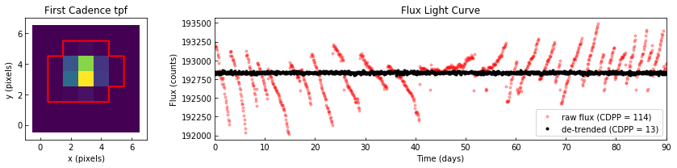

```python
target = scope.generate_target()
target.plot()
```

`generate_target()` can take a stellar magnitude with the mag parameter (defaults to `mag=12.0`). We can easily access the following important parameters: target pixel file light curve (`tpf`), a 1-dimensional flux light curve (`flux`), and a light curve containing the error in each pixel (`err`).

```python
tpf = target.targetpixelfile
flux = target.lightcurve
err = target.error
```

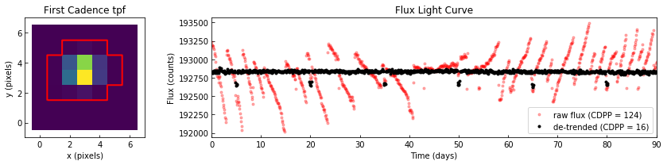

```python
target.add_transit().plot()
```

To return a lightcurve de-trended with second order PLD, use the `detrend()` function.

```python
detrended_target = target.detrend()
lc = detrended_target.lightcurve
tpf = detrended_target.targetpixelfile
```

# Variability

Stellar variability can be injected into a light curve in a similar way to injecting transits. To add simple simusoidal variability, call the `add_variability()` function. `add_variability()` can take amplitude (`var_amp`) and frequency (`freq`).

Alternatively, a custom variability array of length `target.ncadences` can be passed into `add_variability()` with the `custom_variability` parameter.

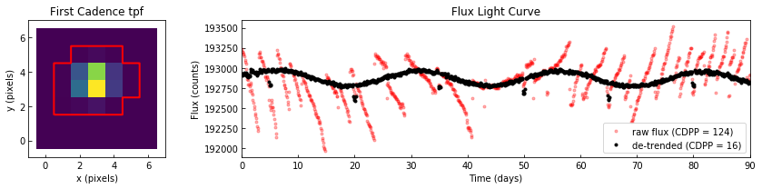

```python
target.add_variability().plot()
```

# High Roll

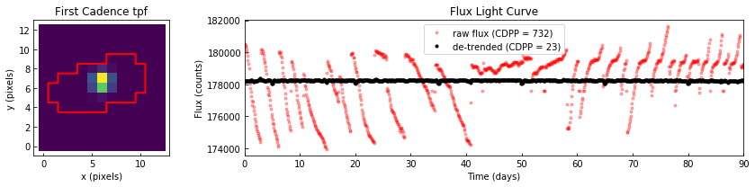

```python
scope.generate_target(roll=5, apsize=13).add_transit().plot()
```

# Default Target Parameters

Alternatively, a `Target` can be instantiated with both variability and transits with default parameters by calling

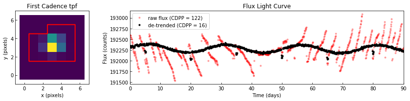

```python
scope.generate_target(transit=True, variable=True).plot()
```

# Detector and Aperture

The CCD detector (with given parameters, or default if no parameters given) and aperture can be displayed with the `display_detector()` and `display_aperture()` functions.

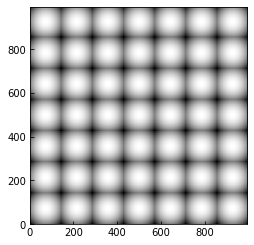

```python
target.display_detector()
```

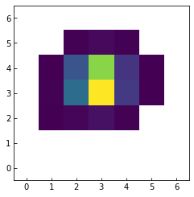

```python
target.display_aperture()
```